# Autoregressive model

# **The Concept of AR processes**

## **1.1. AR($q$) Model**

An autoregressive model is a model where the outcome varibale depends linearly on its previous values and on a stochastic term which is imperfectly predictable. **AR(1)** is called the first order autoregressive process. The outcome variable in a first order AR process at some point in time t is related only to the time periods that are one period apart. **AR(1)** difference equation looks as follows:
$$y_t = \delta + y_{t-1} + \varepsilon_t$$

The **AR(p)** model establishes that a realization at time t is a linear combination of the p previous realization plus some noise. It thus has multiple carryover coefficients instead of just one.
$$X_t = \delta + \sum_{j=1}^{p}\varphi_jX_{t-j}+\varepsilon_t$$

### **1.2. Key Assumptions**

- Errors are independently distributed with a normal distribution that has a 0 mean. $w_t \overset{iid}{\sim} N(0, \sigma^2_w)$
- Properties of the errors $\varepsilon$ are independent of *Y*
- No outliers
- Mean $\mu$ of the time series is constant over time, refute $|\varphi|<1$ (**stationarity**)
- Variance $\sigma$ of the series is constant over time $|\varphi| \neq 1$ (**stationarity**)
- There should be **no seasonal component** (**stationarity**)

### **1.3. The ‘Long Memory’ Model**

An AR model is a long memory model because of the recursion that goes back until the beginning of the series. Today depends on the day before, which depends on the day before that, which depends on the day before that… etc. Let’s say we have the following equation for two terms with AR process.

Value of tomorrow ($Y_t$) is dependent on the value of today ($Y_t$) with theoretical error of today.
$$Y_t = \delta + \varphi Y_{t-1}+\varepsilon_t$$
The value of today is dependent on the day before with its corresponding error.
$$Y_{t-1} = \delta + \varphi Y_{t-2}+\varepsilon_{t-1}$$
In sum, the value of tomorrow ($Y_t$) is going to be slighlty dependent on that of yesterday and today.
$$\begin{aligned}
Y_t &= \delta + \varphi (\delta + \varphi Y_{t-2}+ \varphi \varepsilon_{t-1}) + \varepsilon_t \\
Y_t &= \delta^* + \varphi^2Y_{t-2}+\varphi\varepsilon_{t-1}+\varepsilon_t
\end{aligned}$$

And so on for $Y_\infty$… If you trace back all the way to the beginning of your time series, you will notice that the first term of the time series can still have an effect, albeit (hopefully) a very minimal effect at that. The effects of these first terms have little effect on the present IF $|\varphi |<1$. Else, it will diverge or become a random walk.

> *‘Every new value for our outcome variable $Y_t$ is calculated upon the previous one $Y_{t-1}$ with some coefficient $\varphi$. Therefore, there will always be at least some information of every lag included in the present-day prediction.’*

This is precisely why **stationarity** is an important prerequisite for AR(q) processes. If the series were to be non-stationary, the overall correlation for the chain of *k* lags would always be high because every previous outcome is a really good indicator of what the next one will be like. If we don’t deal with the absence of **stationarity**, we end up missing out on the information of how things change throughout the evolution.

### **1.4. When is an AR($q$) Process Present and at what order?**

An **AR($q$)** process is present when the **autocorrelation** between $Y_t$ and each previous lag decays slowly. This makes sense because the **AR($q$)** model is built on the idea that each previous lag has a part in predicting the following lag. Every lag in the model is used (to some extent) to predict $Y_t$. To predict $Y_t$, the previous lag $Y_{t-1}$ is used directly, but all other possible lags $Y_{t- (>1)}$ are used indirectly since $Y_{t-1}$ was predicted using $Y_{t-2}$, which was predicted using $Y_{t-3}$, …, etc. It’s like a chain reaction! The ACF decays as lags increase because each incremental lag will cause the impact of the value at that lag ($Y_{t-x}$) to be *less direct* in a sense. Please note: **this under the assumption that $|\varphi| < 1$**.

The **order** of an **AR($q$)** process is a representation of how many lags $Y_{t-x}$ in the total time series are able to explain $Y_t$ in a **unique manner**. For an **AR($q$)** process to be present, there must be at least one lag $Y_{t-x}$ that can explain $Y_t$. If this is not the case, The time seires is simply **white noise**.

The PACF (**partial autocorrelation**) is a useful way to constitute how many lags are seperately useful in predicting $Y_t$. That’s because the PACF controls for serial correlation. Thereby, we get to see the ‘isolated’ correlation between $Y_t$ and $Y_{t-x}$. Naturally, each lag will be related to $Y_t$ because an **AR($q$)** process works like a chain reaction whereby the value of $Y$ at any lag will always be a product of the previous values of $Y$. The PACF (**partial autocorrelation**) removes this chain effect by statistically controlling for it. In this manner, we discover the so-called **order** of the **AR($q$)** process.

> *‘Just because the sales amount of two days ago $Y_{t-2}$ is related to the sales amount of today $Y_t$, does not mean that it helps in predicting today’s sales amount $Y_t$ in a **different way** than does yesterday’s sales amount $Y_{t-1}$, or any other lag $Y_{t-x}$ for that matter. That’s why a PACF is useful in determining the order of an AR($q$) process.’*

### **1.5. Why and How an AR(1) Model is an MA($\infty$) Model**

There are two important parts in understanding how this works:

- In an **AR($q$)** Process, the current prediction $Y_t$ is indirectly a product of all previous values of $Y$.
- The MA(1) model predicts $Y_t$ on the basis of an independent shock in the mean of the previous lag $\varepsilon_{t-1}$.

If we interpret every previous lag as an independent shock of the mean up to all possible $\infty$ lags, we can estimate $Y_t$ using MA($\infty$) in the exact same way as we did using AR(1). Transforming an infinite geometric lag model to a finite model with lagged dependent variable is known as the **Koyck Transformation**. A more comprehensive explanation is provided on the page about **invertibility**.

# **2. Practical Relevance**

## **2.1. The good**

AR models are built on the premise that the future will resemble the past. Hence, it’s nickname ‘The Long Memory Model’. Thus, if you are able to quantify relevant aspects of the past well, an AR model can be used to predict the future.

> *‘AR models are good at capturing things from the past that continue into the future.’*

An example is advertising. You advertisements of today will not only affect your sales of tomorrow. Advertising also has a more subconscious and indirect effect. Exposure to many advertisements in the past will make the brand more salient to consumers, which positively affects their attitude and behaviour with regard to your brand. AR models are built to capture such processes.

## **2.1. The Bad**

Its greatest strength can be considered its greatest limitation. The AR model assumes that past changes in ($Y_{t-x}$) at any previous point in time are always going to have a lasting impact on future values of $Y$. Even long after the changes have occurred, at least a fraction of this change will be present in the overall prediction of a future $Y$. This is totally fine if the exogeneous variable that causes changes in values for the predicted variable $Y$ (variables outside of the model) - such as sales - truly has a lasting impact over time. However, this is not always the case!

> *‘In life, things sometimes happen arbitrarily and the fact that these things happen don’t carry any significant meaning in predicting the future.’*

An example is competitor out-of-stocks. It can happen that your major competitor has just experienced a supply-chain crisis and cannot provide its customers with products. These customers will temporarily buy from you, causing a spike in sales until your competitor fixed its problems. Fair enough, some customers might like your products and decide to stick around. However, this is a one time thing. After your competitor is back in business, there will likely not be a structural increase in sales to the same extent as during the months in which the competitor’s crisis had occurred. An **AR($q$)** model does not allow for this distinction and would hence become less accurate if these ‘random shocks’ were not treated as ‘random’. This is were **MA models** come in handy!

## **2. Practical Example Using R**

### **2.1. Plotting the Time Series Data**

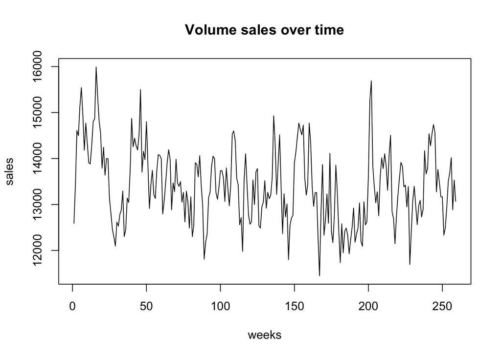

```r
plot(food.df[,c(1)],food.df[,c(2)], type="l", col="black", lwd=1, xlab="weeks", ylab="sales", main="Volume sales over time")
```

### **2.2. Testing for Stationarity**

In the previous section, we established that stationarity is an important prerequisite for AR(q) processes. There are several options for statistical tests in R.

#### **2.2.1. Augmented Dickey Fuller Test**

```r
adf.test(food.df[,c(2)])
```

```
## Augmented Dickey-Fuller Test
## alternative: stationary
##
## Type 1: no drift no trend
##      lag    ADF p.value
## [1,]   0 -0.349   0.543
## [2,]   1 -0.365   0.539
## [3,]   2 -0.419   0.523
## [4,]   3 -0.395   0.530
## [5,]   4 -0.488   0.504
## Type 2: with drift no trend
##      lag   ADF p.value
## [1,]   0 -6.97    0.01
## [2,]   1 -6.50    0.01
## [3,]   2 -5.56    0.01
## [4,]   3 -5.05    0.01
## [5,]   4 -5.18    0.01
## Type 3: with drift and trend
##      lag   ADF p.value
## [1,]   0 -7.28    0.01
## [2,]   1 -6.82    0.01
## [3,]   2 -5.80    0.01
## [4,]   3 -5.28    0.01
## [5,]   4 -5.37    0.01
## ----
## Note: in fact, p.value = 0.01 means p.value <= 0.01
```

#### **2.2.2. Phillips-Perron Test**

```r
pp.test(food.df[,c(2)])
```

```
## Phillips-Perron Unit Root Test
## alternative: stationary
##
## Type 1: no drift no trend
##  lag  Z_rho p.value
##    5 -0.114   0.666
## -----
##  Type 2: with drift no trend
##  lag Z_rho p.value
##    5   -84    0.01
## -----
##  Type 3: with drift and trend
##  lag Z_rho p.value
##    5 -90.9    0.01
## ---------------
## Note: p-value = 0.01 means p.value <= 0.01
```

```r
adf.test(food.df[,c(2)])
```

[output not shown]

#### **2.3. determining type and order with ACF & PACF**

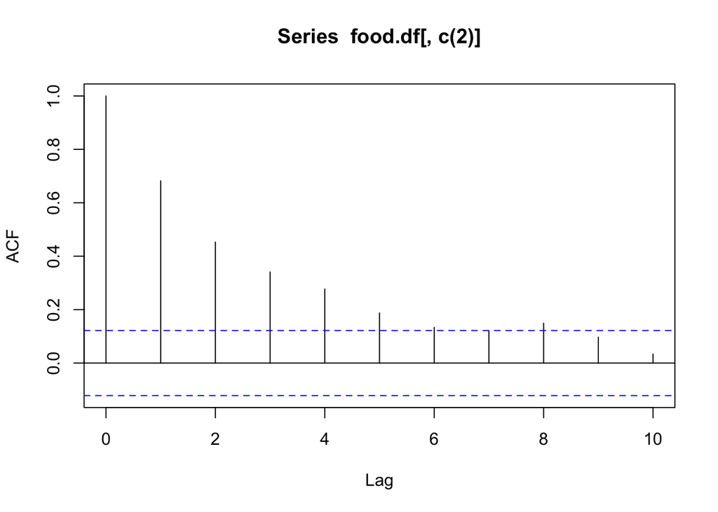

```r
foodacf = acf(food.df[,c(2)], lag.max = 10)
```

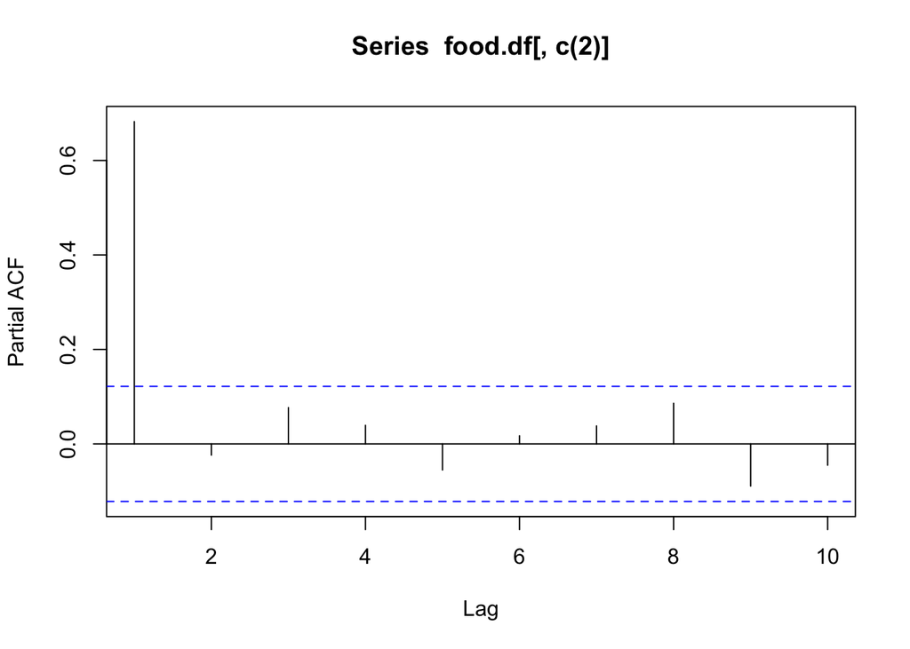

```r
foodpacf = pacf(food.df[,c(2)], lag.max = 10)
```

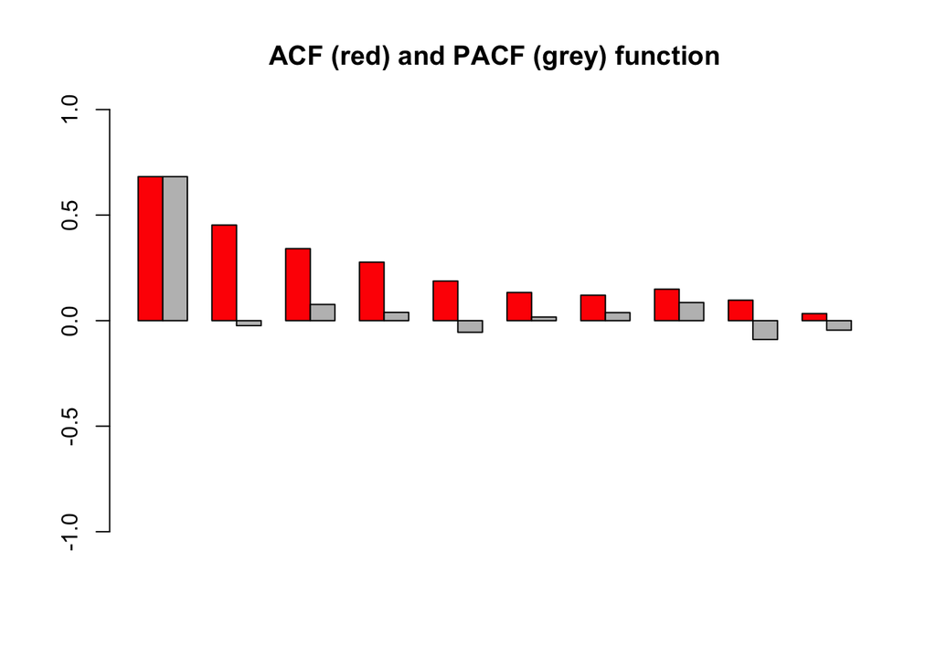

```r
barplot(bartry6, ylim = c(-1,1), main = "ACF (red) and PACF (grey) function", col = c("red", "grey"), beside = TRUE)
```

### **2.4. auto.arima test**

```r
foodsel = food.df[,c(2)]
tsfoodsel = as.ts(foodsel)
auto.arima(tsfoodsel, test = c("adf"), trace = TRUE)
```

```
##
##  Fitting models using approximations to speed things up...
##
##  ARIMA(2,0,2) with non-zero mean : Inf
##  ARIMA(0,0,0) with non-zero mean : 4218.109
##  ARIMA(1,0,0) with non-zero mean : 4056.921
##  ARIMA(0,0,1) with non-zero mean : 4104.513
##  ARIMA(0,0,0) with zero mean     : 5660.984
##  ARIMA(2,0,0) with non-zero mean : 4058.826
##  ARIMA(1,0,1) with non-zero mean : 4058.657
##  ARIMA(2,0,1) with non-zero mean : Inf
##  ARIMA(1,0,0) with zero mean     : Inf
##
##  Now re-fitting the best model(s) without approximations...
##
##  ARIMA(1,0,0) with non-zero mean : 4057.532
##
##  Best model: ARIMA(1,0,0) with non-zero mean
```

```
## Series: tsfoodsel
## ARIMA(1,0,0) with non-zero mean
##
## Coefficients:
##          ar1        mean
##       0.6827  13401.3372
## s.e.  0.0452    117.0434
##
## sigma^2 estimated as 365883:  log likelihood=-2025.72
## AIC=4057.44   AICc=4057.53   BIC=4068.11
```